# Are doctors spending less time with patients?

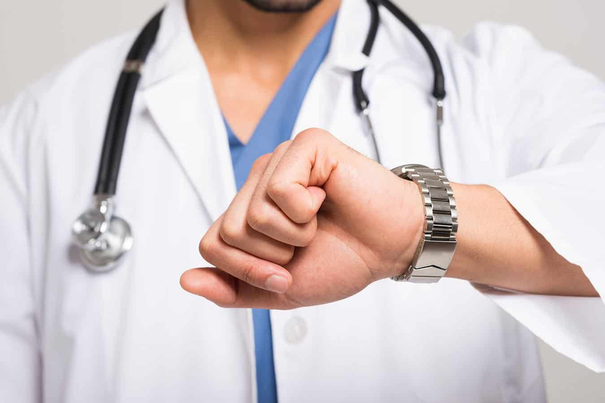

Posted by [Remy Franklin](https://mobius.md/author/rfranklin/) on October 9, 2021 | Featured

Patient visits are changing. In 2020, COVID-19 ushered in [telehealth](https://mobius.md/2021/05/19/telehealth-covid-19-5-numbers-physicians-should-know/). And in just the past decade, nearly every physician started using electronic health records. This infusion of health IT into clinical encounters means physicians have changed their documentation workflows and are approaching patient visits differently. Amidst these changes, are doctors spending less time with patients?

## Are doctors spending less time with patients?

The short answer is “no.” While it’s hard to pin down a meaningful average for something like patient visit times, studies indicate that doctors have spent roughly 13 to 24 minutes with patients for at least the past three decades.

Data from the 1990s reveal some [debates about the average time](https://www.ncbi.nlm.nih.gov/pmc/articles/PMC2254573/) physicians spend with patients. Surveys from those years placed the average around 17 minutes, but competing studies claimed the real number was closer to 10 minutes. Other research found that physicians and their staff tend to [overreport](https://www.ncbi.nlm.nih.gov/pmc/articles/PMC2254573/) patient visit times by about 4 minutes, on average.

Research published in 2021 used time-stamped EHR data from over 21 million primary care visits to estimate average exam length. The authors conclude that the average primary care exam lasts 18 minutes, which is consistent with estimates derived from more common methods like retrospective surveys.

A review of [2018 data](https://www.statista.com/statistics/250219/us-physicians-opinion-about-their-compensation/) suggests that most U.S. physicians spend between 13 and 24 minutes with patients. About 1 in 4 spend less than 12 minutes, and roughly 1 in 10 spend more than 25 minutes. All in all, it seems like doctor-patient time isn’t changing substantially.

While about half of physicians did report experiencing a permanent reduction in patient volume due to COVID-19, for most the impact has been marginal. The weekly average number of patients doctors see dropped from [76 to 71](https://www.medscape.com/slideshow/2021-compensation-overview-6013761#18) after the pandemic, which predictable variation across specialties. This reduction may affect visit times, but there is not yet reliable data to confirm either way.

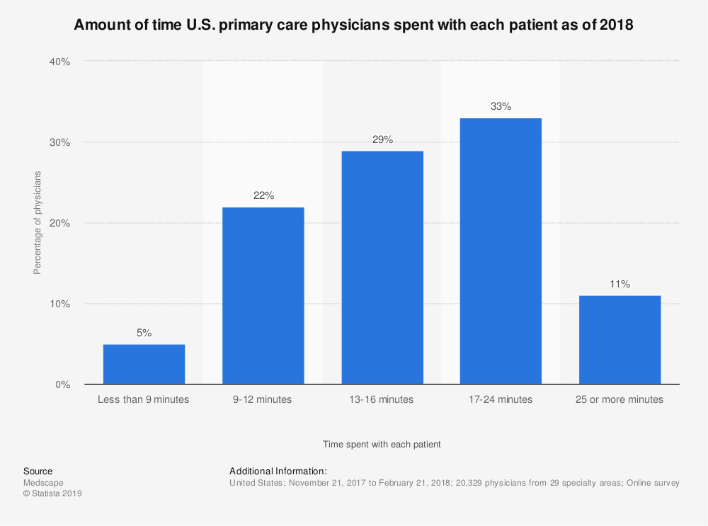

## Have EHRs changed the length of patient visits?

Much of the U.S. survey data come from [Medscape’s annual Physician Compensation Report](https://www.medscape.com/slideshow/2021-compensation-overview-6013761), which surveys roughly 18,000 doctors about things like their salary, hours worked, and time spent with patients. Presumably their survey would register any notable changes to how long doctors are spending with patients in each visit.

Contrary to what you might expect, physician-patient time has remained pretty constant since the adoption of EHRs. In the 2018 survey, when time spent with patients was last reported, 61 percent of physicians reporrted spending 1[3-24 minutes with patients](https://www.medscape.com/slideshow/2018-compensation-overview-6009667#32). In 2016 that number was 60 percent. Responses look similar in Medscape’s annual surveys going back to 2011.

The reason visit times haven’t dropped is probably that physicians enjoy interacting with patients. Gratitude and relationships with patients is the aspect their job that doctors say is most rewarding (in 2021 this was matched by “knowing that I’m making the world a better place”).

Research shows that when limits are put on time with patients, physicians [experience less job satisfaction](https://link.springer.com/article/10.1007/s11606-008-0596-y). Longer visits are also connected to [positive patient outcomes](https://www.ncbi.nlm.nih.gov/pmc/articles/PMC1496869/). When patients get more time with doctors, they tend to be more satisfied with their care, experience reduced rates of medication prescriptions, and be less likely to file malpractice claims.

## So what’s the problem?

So why are so many physicians struggling in medicine or leaving the field? [Physician burnout is skyrocketing](http://45.33.12.216/blog/2019/04/how-bad-is-physician-burnout/). It seems like more and more doctors are seeing a gap between the values that brought them to medicine and their day to day reality. But what’s causing the disconnect?

Patient visit times are about as long as they’ve always been. It’s the rest of physicians’ work days that’s changing. Doctors are spending more time than ever on documentation and administrative tasks, leading to dissatisfaction and professional burnout.

Here’s the number that’s shocking: in 2021 doctors reported spending on average [15.6 hours per week](https://www.medscape.com/slideshow/2021-compensation-overview-6013761#21) on paperwork and other administrative tasks. This reflects a trend that’s emerged in the last decade. In 2018, 70 percent of physicians said they spend [over 10 hours per week](https://www.medscape.com/slideshow/2018-compensation-overview-6009667#33) on paperwork and administrative tasks. In 2017, that number was [57 percent](http://www.medscape.com/slideshow/compensation-2017-overview-6008547#33). But just one-third of physicians reported the same experience in 2014.

Most physicians’ would tell you that their experience of practicing medicine is different than it was a decade ago. But when we look at the numbers, it’s not patient visit times that are changing. It’s everything else.